# Laborarbeit Künstliche Intelligenz

## Thema : Bayes Netze und Case Based Reasoning

### Namen des/r Studierenden:

Niklas Werthmann

### Setup: Bibliotheken laden und Datensatz importieren

```python
import pandas as pd
import matplotlib.pyplot as plt
import seaborn as sns
from sklearn.metrics import accuracy_score, classification_report, confusion_matrix, ConfusionMatrixDisplay
import numpy as np
from pgmpy.models import BayesianNetwork
from pgmpy.factors.discrete import TabularCPD
from pgmpy.inference import VariableElimination

plt.set_loglevel("warning") # Setze den Log-Level für Matplotlib auf "warning"

# Einlesen der CSV-Datei
file_path = './bikedata/sampled_data_004.csv'
data = pd.read_csv(file_path, sep=";", decimal=",")
```

### Datenbereinigung

#### Suche nach NaN Werten

```python
print(data.isna().sum())
```

```
Distance           0
Elapsed Time       0
Elevation High     0
Elevation Gain     0
Weekday            0
Bike Type         58
dtype: int64
```

Wir sehen, dass lediglich der `Bike Type` bei einigen Daten nicht bekannt ist. Da dies unsere Zielvariable ist, entfernen wir diese Datensätze.

```python
data = data.dropna()
```

## Explorative Datenanalyse

```python
data.head()
```

|  | Distance | Elapsed Time | Elevation High | Elevation Gain | Weekday | Bike Type |
| --- | --- | --- | --- | --- | --- | --- |
| 2 | 40.27 | 22875 | 2279.9 | 494.11 | Saturday | mtb |
| 3 | 3.23 | 1233 | 539.0 | 21.00 | Wednesday | race bike |
| 4 | 35.40 | 6199 | 371.0 | 157.00 | Wednesday | trecking bike |
| 5 | 65.38 | 10591 | 530.2 | 937.00 | Saturday | race bike |
| 6 | 52.38 | 7940 | 615.8 | 721.00 | Saturday | race bike |

```python
data.info()
```

```
<class 'pandas.core.frame.DataFrame'>
Index: 189 entries, 2 to 246
Data columns (total 6 columns):
 #   Column          Non-Null Count  Dtype
---  ------          --------------  -----
 0   Distance        189 non-null    float64
 1   Elapsed Time    189 non-null    int64
 2   Elevation High  189 non-null    float64
 3   Elevation Gain  189 non-null    float64
 4   Weekday         189 non-null    object
 5   Bike Type       189 non-null    object
dtypes: float64(3), int64(1), object(2)
memory usage: 10.3+ KB
```

```python
data.describe()
```

|  | Distance | Elapsed Time | Elevation High | Elevation Gain |
| --- | --- | --- | --- | --- |
| count | 189.000000 | 189.000000 | 189.000000 | 189.000000 |
| mean | 40.362381 | 6947.867725 | 458.780423 | 412.484603 |
| std | 27.906235 | 5312.384989 | 322.351340 | 479.385288 |
| min | 3.230000 | 952.000000 | -120.600000 | 13.800000 |
| 25% | 28.300000 | 4697.000000 | 329.000000 | 146.000000 |
| 50% | 35.250000 | 5666.000000 | 416.200000 | 279.000000 |
| 75% | 41.890000 | 6810.000000 | 501.000000 | 517.000000 |
| max | 219.320000 | 45073.000000 | 2766.800000 | 4838.000000 |

Wir betrachten die Verteilung der Zielvariablen

```python
print(data['Bike Type'].value_counts())
```

```
Bike Type
race bike        105
trecking bike     61
mtb               23
Name: count, dtype: int64
```

Umwandlung in %:

```python
print(data['Bike Type'].value_counts(normalize=True) * 100)
```

```
Bike Type
race bike        55.555556
trecking bike    32.275132
mtb              12.169312
Name: proportion, dtype: float64
```

Und die deskriptive Statistik der Daten für jeden `Bike Type`

```python
grouped_data = data.groupby('Bike Type')
for bike_type, group in grouped_data:
    print(f"Descriptive statistics for {bike_type}:\n")
    print(group.describe())
    print("\n" + "-"*70 + "\n")
```

```
Descriptive statistics for mtb:

        Distance  Elapsed Time  Elevation High  Elevation Gain
count  23.000000     23.000000       23.000000       23.000000
mean   17.604348   4560.826087      384.743478      214.761739
std     9.200963   4421.963927      461.970185      121.670654
min     4.250000    952.000000     -120.600000       13.800000
25%    10.955000   2453.500000      170.400000      142.795000
50%    15.640000   3246.000000      359.000000      216.490000
75%    19.710000   4544.000000      413.300000      241.000000
max    40.270000  22875.000000     2279.900000      494.110000

----------------------------------------------------------------------

Descriptive statistics for race bike:

         Distance  Elapsed Time  Elevation High  Elevation Gain
count  105.000000    105.000000      105.000000      105.000000
mean    48.052571   7949.876190      542.256190      588.882000
std     32.171612   6251.371558      352.345925      567.584251
min      3.230000   1233.000000       12.400000       17.230000
25%     30.620000   4825.000000      454.800000      316.000000
50%     36.570000   5909.000000      497.600000      479.000000
75%     51.330000   8364.000000      525.200000      615.000000
max    219.320000  45073.000000     2766.800000     4838.000000

----------------------------------------------------------------------

Descriptive statistics for trecking bike:

         Distance  Elapsed Time  Elevation High  Elevation Gain
count   61.000000     61.000000       61.000000       61.000000
mean    35.706066   6123.131148      343.008197      183.400984
std     17.057845   2981.041532       64.974878      182.905175
min      4.090000   1851.000000       64.600000       48.200000
25%     34.890000   5374.000000      315.400000      123.000000
50%     35.340000   5719.000000      331.000000      144.000000
75%     35.890000   5999.000000      380.200000      161.000000
max    148.490000  21426.000000      543.000000     1444.000000

----------------------------------------------------------------------
```

### Boxplots der numerischen Daten

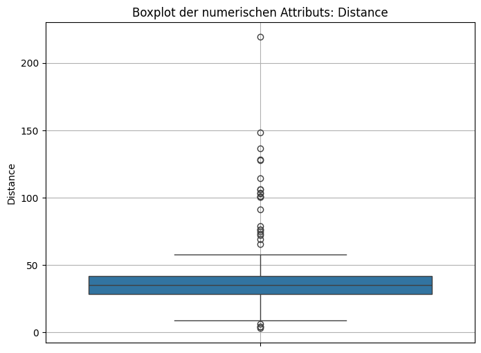

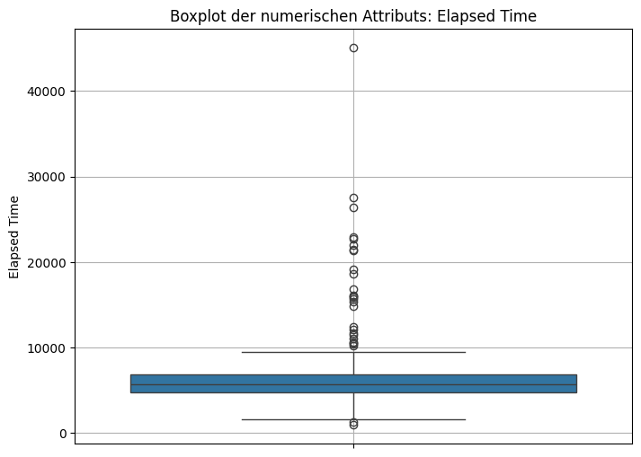

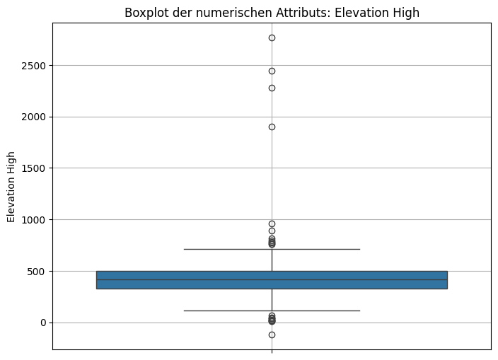

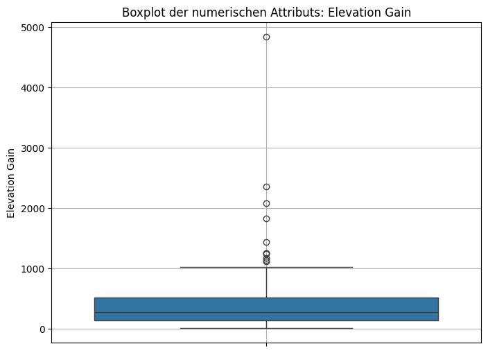

```python
# Numerische Attribute - einzelne Boxplots
numeric_columns = data.select_dtypes(include='number').columns

for column in numeric_columns:
    plt.figure(figsize=(8, 6))
    sns.boxplot(y=data[column])
    plt.title(f'Boxplot der numerischen Attributs: {column}')
    plt.ylabel(column)
    plt.grid(True)
    plt.show()
```

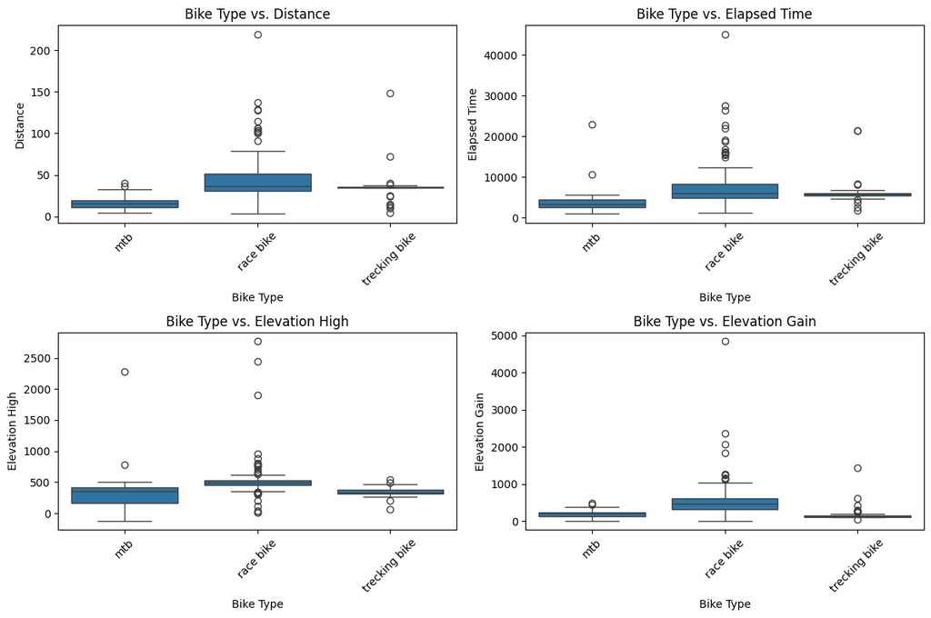

```python
# Boxplots zur Analyse von Bike Type vs. Leistungswerte
plt.figure(figsize=(12, 8))
for i, col in enumerate(['Distance', 'Elapsed Time', 'Elevation High', 'Elevation Gain'], 1):
    plt.subplot(2, 2, i)
    sns.boxplot(x=data['Bike Type'], y=data[col])
    plt.title(f'Bike Type vs. {col}')
    plt.xticks(rotation=45)
plt.tight_layout()
plt.show()
```

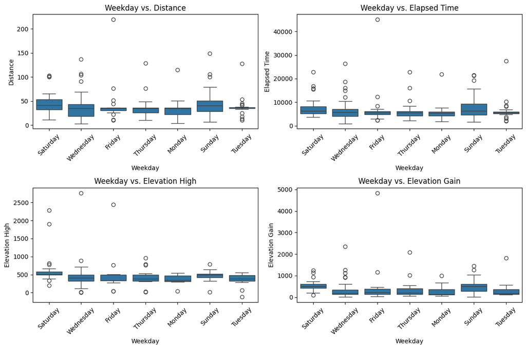

```python
# Boxplots zur Analyse von Weekday vs. Leistungswerte
plt.figure(figsize=(12, 8))
for i, col in enumerate(['Distance', 'Elapsed Time', 'Elevation High', 'Elevation Gain'], 1):
    plt.subplot(2, 2, i)
    sns.boxplot(x=data['Weekday'], y=data[col])
    plt.title(f'Weekday vs. {col}')
    plt.xticks(rotation=45)
plt.tight_layout()
plt.show()
```

### Häufigkeitsverteilungen der kategorialen Variablen

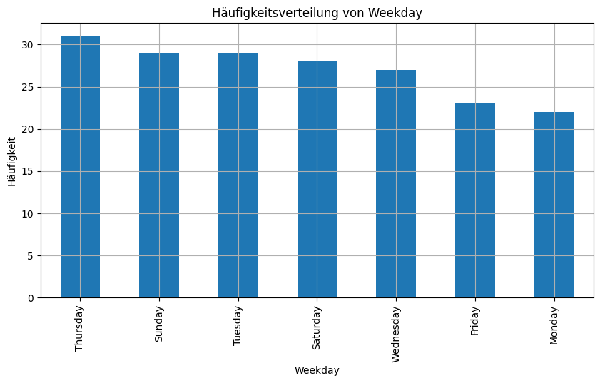

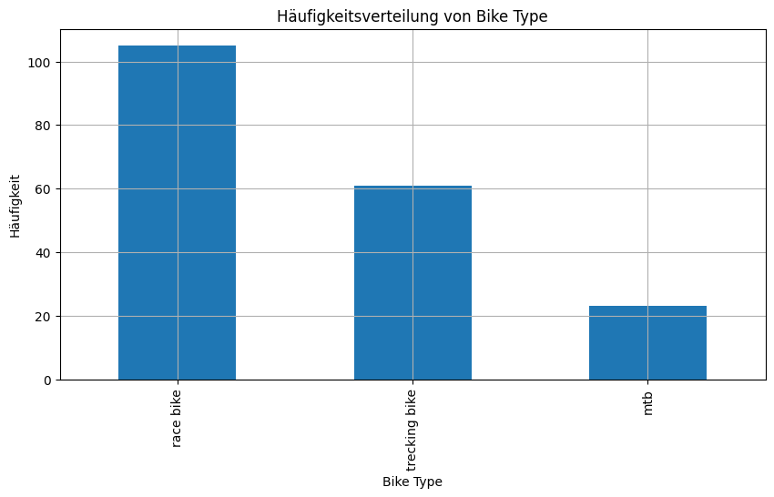

```python
# Kategoriale Attribute - Häufigkeitsverteilungen
categorical_columns = data.select_dtypes(include='object').columns

for column in categorical_columns:
    plt.figure(figsize=(10, 5))
    data[column].value_counts().plot(kind='bar')
    plt.title(f'Häufigkeitsverteilung von {column}')
    plt.xlabel(column)
    plt.ylabel('Häufigkeit')
    plt.grid(True)
    plt.show()
```

### Scatterplot von Elevation Gain und Distance nach Bike Type

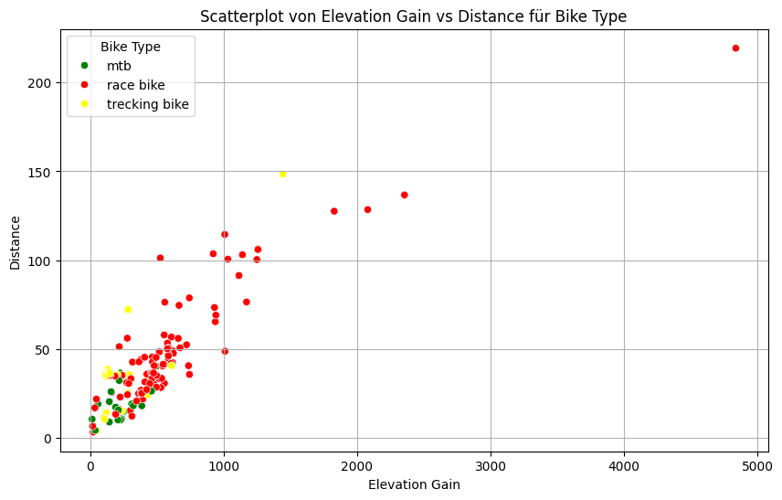

```python
# Scatterplot für Elevation Gain und Distance basierend auf Bike Type

plt.figure(figsize=(10, 6))
colors = {'race bike': 'red', 'mtb': 'green', 'trecking bike': 'yellow'}
sns.scatterplot(data=data, x='Elevation Gain', y='Distance', hue='Bike Type', palette=colors)
plt.title('Scatterplot von Elevation Gain vs Distance für Bike Type')
plt.xlabel('Elevation Gain')
plt.ylabel('Distance')
plt.grid(True)
plt.show()
```

### Verteilung der Bike Types über die Wochentage

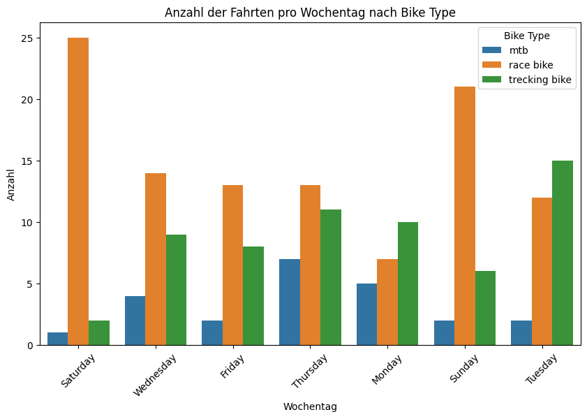

```python
plt.figure(figsize=(10, 6))
sns.countplot(data=data, x='Weekday', hue='Bike Type')
plt.title('Anzahl der Fahrten pro Wochentag nach Bike Type')
plt.xlabel('Wochentag')
plt.ylabel('Anzahl')
plt.xticks(rotation=45)
plt.legend(title='Bike Type')
plt.show()
```

### Korrelationsmatrix der numerischen Daten

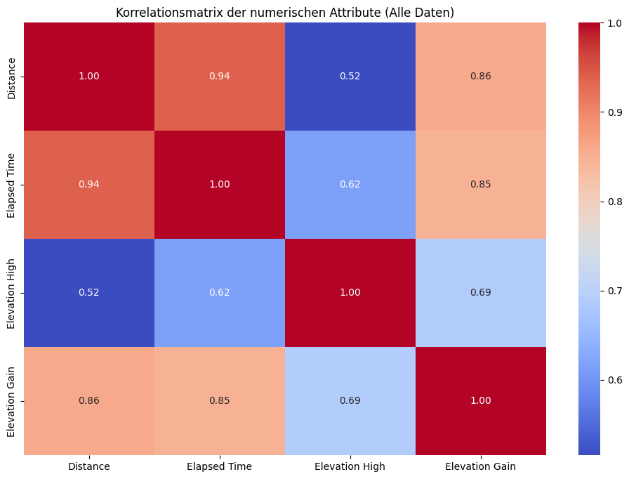

```python
correlation_matrix = data[['Distance', 'Elapsed Time', 'Elevation High', 'Elevation Gain']].corr()

plt.figure(figsize=(12, 8))
sns.heatmap(correlation_matrix, annot=True, fmt=".2f", cmap="coolwarm", cbar=True)
plt.title('Korrelationsmatrix der numerischen Attribute (Alle Daten)')
plt.show()
```

### Korrelationsmatrix der numerischen Daten je Bike Type

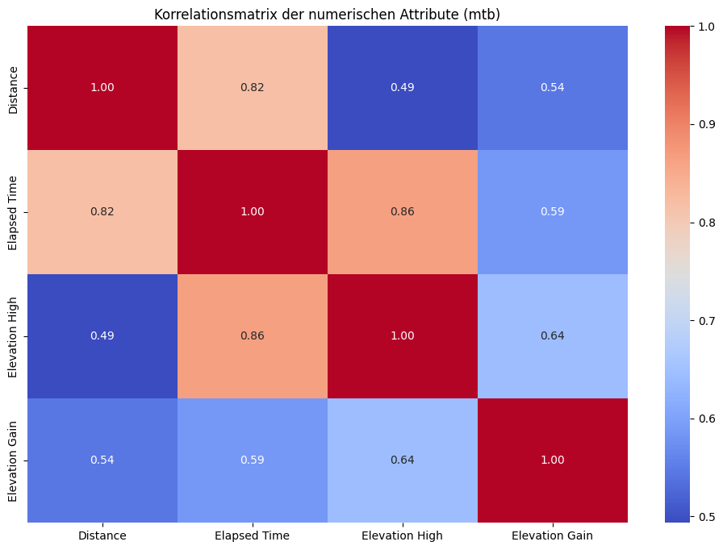

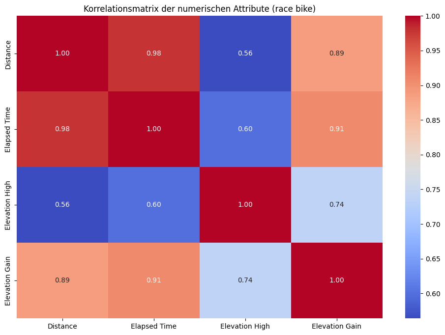

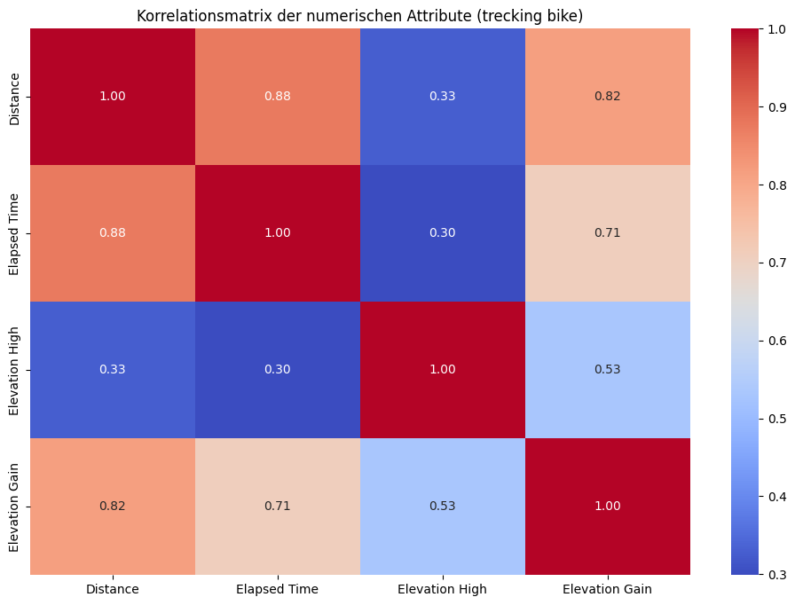

```python
# Group the data by 'Bike Type' and calculate the correlation matrix for each group
for bike_type, group in data.groupby('Bike Type'):
    correlation_matrix = group[['Distance', 'Elapsed Time', 'Elevation High', 'Elevation Gain']].corr()

    # Plot the heatmap for the correlation matrix
    plt.figure(figsize=(12, 8))
    sns.heatmap(correlation_matrix, annot=True, fmt=".2f", cmap="coolwarm", cbar=True)
    plt.title(f'Korrelationsmatrix der numerischen Attribute ({bike_type})')
    plt.show()
```

## Aufgabenteil 1: Bayes Netze

Aufgabe: "Entwerfen Sie ein KI Modell auf Basis der Bayes Netze und setzen Sie dieses als Jupyter Notebook um. Insbesondere wird eine geeignete Netzarchitektur und ein Vorschlag für eine plausible Wahrscheinlichkeitsverteilung benötigt."

Wir beginnen mit der Definition des Bayes’schen Netzwerks und legen die kausalen Abhängigkeiten zwischen den Eingabemerkmalen und dem Zielmerkmal `Bike Type` fest.

### 1. Modell anlegen

```python
model = BayesianNetwork([
    ('Distance', 'Bike Type'),
    ('Elapsed Time', 'Bike Type'),
    ('Elevation High', 'Bike Type'),
    ('Elevation Gain', 'Bike Type'),
    ('Weekday', 'Bike Type'),
])
```

### 2. CPTs anlegen

In diesem Abschnitt definieren wir die *Conditional Probability Tables* (CPTs), die das Herzstück unseres Bayes'schen Netzes bilden. Sie beschreiben die Wahrscheinlichkeitsverteilungen der Variablen – entweder marginal oder bedingt auf ihre Eltern im Netz. Grundlage für die Festlegung der CPTs sind deskriptive Statistiken der Daten sowie sinnvolle Schwellenwerte zur Diskretisierung. Bei geringer Datenverfügbarkeit greifen wir ergänzend auf fachliches Hintergrundwissen und realistische Annahmen zurück.

#### 2.1 Elapsed Time

Basierend auf der deskriptiven Statistik:

| Statistik | Wert |
| --- | --- |
| Anzahl | 189 |
| Mittelwert | ~6948 |
| Standardabweichung | ~5312 |
| Minimum | 952 |
| 25%-Perzentil | 4697 |
| Median | 5666 |
| 75%-Perzentil | 6810 |
| Maximum | 45073 |

##### Diskretisierungsregeln:

- **low**: Elapsed Time ≤ 5666 (unterhalb des Medians)
- **medium**: 5666 < Elapsed Time ≤ 6810 (zwischen Median und 75%)
- **high**: Elapsed Time > 6810 (oberhalb des 75%-Perzentils)

##### Begründung:

- **low**: Kurze, eventuell alltägliche Fahrten.
- **medium**: Mittellange Touren.
- **high**: Lange oder außergewöhnliche Fahrten.

##### Nächster Schritt:

Berechnung der Wahrscheinlichkeitsverteilung für die diskretisierten Werte.

```python
print(pd.cut(data['Elapsed Time'],bins=[0, 5666, 6810, np.inf], labels=['low', 'medium', 'high']).value_counts(normalize=True).sort_index())
```

```
Elapsed Time
low       0.502646
medium    0.248677
high      0.248677
Name: proportion, dtype: float64
```

##### Erstellung der CPT für Elapsed Time

```python
# Wir erhalten:
# low      ~0.5026
# medium   ~0.2487
# high     ~0.2487

# Dann ist die CPT wie folgt:
cpd_elapsed_time = TabularCPD(
    variable='Elapsed Time',
    variable_card=3,
    values=[
        [0.5026],    # P(low)
        [0.2487],   # P(medium)
        [0.2487]    # P(high)
    ],
    state_names={'Elapsed Time': ['low', 'medium', 'high']})
```

#### 2.2 Distance

Basierend auf der deskriptiven Statistik:

| Statistik | Wert |
| --- | --- |
| Anzahl | 189 |
| Mittelwert | ~40.36 |
| Standardabweichung | ~27.91 |
| Minimum | 3.23 |
| 25%-Perzentil | 28.30 |
| Median | 35.25 |
| 75%-Perzentil | 41.89 |
| Maximum | 219.32 |

##### Diskretisierungsregeln:

- **short**: Distance ≤ 35.25 (unterhalb des Medians)
- **medium**: 35.25 < Distance ≤ 41.89 (zwischen Median und 75%)
- **long**: Distance > 41.89 (oberhalb des 75%-Perzentils)

##### Begründung:

- **short**: Kürzere Strecken, die typischerweise alltägliche Fahrten darstellen.
- **medium**: Mittellange Strecken, die zwischen alltäglichen und längeren Touren liegen.
- **long**: Längere Strecken, die außergewöhnliche oder sportliche Fahrten repräsentieren.

##### Nächster Schritt:

Berechnung der Wahrscheinlichkeitsverteilung für die diskretisierten Werte.

```python
print(pd.cut(data['Distance'], bins=[0, 35.25 , 41.89, np.inf], labels=['short', 'medium', 'long']).value_counts(normalize=True).sort_index())
```

```
Distance
short     0.502646
medium    0.248677
long      0.248677
Name: proportion, dtype: float64
```

##### Erstellung der CPT für Distance

```python
# Wir erhalten:
# short      ~0.5026
# medium   ~0.2487
# long     ~0.2487

# Dann ist die CPT wie folgt:
cpd_distance = TabularCPD(
    variable='Distance',
    variable_card=3,
    values=[
        [0.5026],    # P(short)
        [0.2487],   # P(medium)
        [0.2487]    # P(long)
    ],
    state_names={'Distance': ['short', 'medium', 'long']}
)
```

#### 2.3 Elevation High

Basierend auf der deskriptiven Statistik:

| Statistik | Wert |
| --- | --- |
| Anzahl | 189 |
| Mittelwert | ~458.78 |
| Standardabweichung | ~322.35 |
| Minimum | -120.6 |
| 25%-Perzentil | 329.0 |
| Median | 416.2 |
| 75%-Perzentil | 501.0 |
| Maximum | 2766.8 |

##### Diskretisierungsregeln:

- **low**: Elevation High ≤ 416.2 (unterhalb oder gleich dem Median)
- **high**: Elevation High > 416.2 (oberhalb des Medians)

##### Begründung:

- **low**: Niedrigere Höhenlagen, die typischerweise alltägliche oder weniger anspruchsvolle Fahrten darstellen.
- **high**: Höhere Höhenlagen, die außergewöhnliche oder sportliche Fahrten repräsentieren.

##### Nächster Schritt:

Berechnung der Wahrscheinlichkeitsverteilung für die diskretisierten Werte.

```python
print(pd.cut(data['Elevation High'], bins=[-np.inf, 416.2, np.inf], labels=['low', 'high']).value_counts(normalize=True).sort_index())
```

```
Elevation High
low     0.502646
high    0.497354
Name: proportion, dtype: float64
```

##### Erstellung der CPT für Elevation High

```python
# Wir erhalten:
# low     ~0.5026
# high    ~0.4974

# Dann ist die CPT wie folgt:
cpd_elevation_high = TabularCPD(
    variable='Elevation High',
    variable_card=2,
    values=[
        [0.5026],  # P(low)
        [0.4974]   # P(high)
    ],
    state_names={'Elevation High': ['low', 'high']}
)
```

#### 2.4 Elevantion Gain

Basierend auf der deskriptiven Statistik:

| Statistik | Wert |
| --- | --- |
| Anzahl | 189 |
| Mittelwert | ~412.48 |
| Standardabweichung | ~479.39 |
| Minimum | 13.80 |
| 25%-Perzentil | 146.00 |
| Median | 279.00 |
| 75%-Perzentil | 517.00 |
| Maximum | 4838.00 |

##### Diskretisierungsregeln:

- **low**: Elevation Gain ≤ 279 (unterhalb oder gleich dem Median)
- **medium**: 279 < Elevation Gain ≤ 517 (zwischen Median und 75%-Perzentil)
- **high**: Elevation Gain > 517 (oberhalb des 75%-Perzentils)

##### Begründung:

- **low**: Geringe Höhengewinne, die typischerweise alltägliche oder weniger anspruchsvolle Fahrten darstellen.
- **medium**: Mittlere Höhengewinne, die zwischen alltäglichen und sportlicheren Fahrten liegen.
- **high**: Hohe Höhengewinne, die außergewöhnliche oder sportliche Fahrten repräsentieren.

##### Nächster Schritt:

Berechnung der Wahrscheinlichkeitsverteilung für die diskretisierten Werte.

```python
print(pd.cut(data['Elevation Gain'], bins=[0, 279, 517, np.inf], labels=['low', 'medium', 'high']).value_counts(normalize=True).sort_index())
```

```
Elevation Gain
low       0.502646
medium    0.248677
high      0.248677
Name: proportion, dtype: float64
```

##### Erstellung der CPT für Elevation Gain

```python
# Wir erhalten:
# low     ~0.5026
# medium  ~0.2487
# high    ~0.2487

# Dann ist die CPT wie folgt:

cpd_elevation_gain = TabularCPD(
    variable='Elevation Gain',
    variable_card=3,
    values=[
        [0.5026],   # P(low)
        [0.2487],   # P(medium)
        [0.2487]    # P(high)
    ],
    state_names={'Elevation Gain': ['low', 'medium', 'high']}
)
```

#### 2.5 Weekday

##### Diskretisierungsregel:

Wir unterteilen Weekday in zwei Kategorien:

- **weekday**: Monday to Friday
- **weekend**: Saturday & Sunday

##### Begründung:

Die EDA zeigte, dass Race Bikes zwar unter der Woche bereits am häufigsten genutzt werden, jedoch ist ihr Anteil am Wochenende im Vergleich zu den anderen Bike Types noch ausgeprägter.

```python
print(data['Weekday'].apply(lambda x: 'weekend' if x in ['Saturday', 'Sunday'] else 'weekday').value_counts(normalize=True).sort_index())
```

```
Weekday
weekday    0.698413
weekend    0.301587
Name: proportion, dtype: float64
```

##### Erstellung der CPT für Weekday

```python
# Wir erhalten:
# weekday    ~0.6984
# weekend    ~0.3016

# Dann ist die CPT wie folgt:
cpd_weekday = TabularCPD(
    variable='Weekday',
    variable_card=2,
    values=[
        [0.6984],   # P(weekday)
        [0.3016]    # P(weekend)
    ],
    state_names={'Weekday': ['weekday', 'weekend']})
```

#### 2.6 Biketype

Die Erstellung der CPT für `Bike Type` gestaltet sich komplexer.  
Wir benötigen die diskretisierten Merkmale, um die bedingte Wahrscheinlichkeit der Zielvariable `Bike Type` zu berechnen.  
Dazu erstellen wir eine Kopie des DataFrames und legen die diskretisierten Bereiche, wie zuvor definiert, fest.

```python
# Wir erstellen eine neue DataFrame-Kopie mit allen diskretisierten Merkmalen
df_cpt = data.copy()

# Diskretisierung (wie oben schon verwendet)
df_cpt['Elapsed Time'] = pd.cut(df_cpt['Elapsed Time'], bins=[0, 5666, 6810, np.inf], labels=['low', 'medium', 'high'])
df_cpt['Distance'] = pd.cut(df_cpt['Distance'], bins=[0, 35.25, 41.89, np.inf], labels=['short', 'medium', 'long'])
df_cpt['Elevation High'] = pd.cut(df_cpt['Elevation High'], bins=[-np.inf, 416.2, np.inf], labels=['low', 'high'])
df_cpt['Elevation Gain'] = pd.cut(df_cpt['Elevation Gain'], bins=[0, 279, 517, np.inf], labels=['low', 'medium', 'high'])
df_cpt['Weekday'] = df_cpt['Weekday'].apply(lambda x: 'weekend' if x in ['Saturday', 'Sunday'] else 'weekday')
```

Nachdem die Diskretisierung abgeschlossen ist, gruppieren wir die Daten nach den diskretisierten Merkmalswerten und zählen, wie häufig jede Kombination dieser Merkmale für den jeweiligen `Bike Type` vorkommt.  
Daraus entsteht eine Häufigkeitstabelle, die die Anzahl der Vorkommen jedes `Bike Type` für jede Merkmalskombination darstellt.

```python
# Jetzt gruppieren wir nach allen Eltern und zählen die Bike Types
grouped = df_cpt.groupby(['Elapsed Time', 'Distance', 'Elevation High', 'Elevation Gain', 'Weekday', 'Bike Type'], observed=False).size()
grouped = grouped.unstack(fill_value=0)
```

Um die bedingte Wahrscheinlichkeit zu berechnen, teilen wir jede Häufigkeit durch die Gesamtsumme der Häufigkeiten für jede Kombination der Merkmale. Dies gibt uns die Wahrscheinlichkeiten, mit denen jeder `Bike Type` für jede Merkmalskombination auftritt.

```python
cpt_bike_type = grouped.div(grouped.sum(axis=1), axis=0)
```

Nun liegen uns die bedingten Wahrscheinlichkeiten für den `Bike Type` in Bezug auf die Merkmale vor.

Bevor wir die Erstellung des CPT für die Zielvariable `Bike Type` abschließen können, müssen wir noch die Vollständigkeit prüfen, da es vorkommen kann, dass einige Kombinationen der Merkmale in den Daten fehlen.  
In diesem Fall füllen wir die fehlenden Kombinationen auf, um sicherzustellen, dass das Bayes’sche Netzwerk alle möglichen Kombinationen der Merkmale berücksichtigen kann.

Wir definieren zunächst die Elternvariablen und die Anzahl der Zustände dieser:

```python
# Elternvariablen in folgender Reihenfolge:
# ['Distance', 'Elapsed Time', 'Elevation High', 'Elevation Gain', 'Weekday']

# Anzahl der Zustände je Variable
# Elapsed Time: 3 (low, medium, high)
# Distance: 3  (short, medium, long)
# Elevation High: 2 (low, high)
# Elevation Gain: 3 (low, medium, high)
# Weekday: 2 (weekday, weekend)

# Bike Type (Zielvariable): 3 Klassen -> ['mtb', 'race bike', 'trecking bike']

# Also:
evidence = ['Elapsed Time', 'Distance', 'Elevation High', 'Elevation Gain', 'Weekday']
evidence_card = [3, 3, 2, 3, 2]
```

Anschließend wird ein vollständiger Satz von Zuständen erzeugt, der alle möglichen Kombinationen der Merkmale umfasst. Fehlende Kombinationen werden mit den spezifischen Wahrscheinlichkeiten für die `Bike Type`-Kategorien aufgefüllt:

```python
# Sicherstellen, dass alle Kombinationen vorhanden sind

all_states = pd.MultiIndex.from_product([
    ['low', 'medium', 'high'],
    ['short', 'medium', 'long'],
    ['low', 'high'],
    ['low', 'medium', 'high'],
    ['weekday', 'weekend']
], names=evidence)

# Erinnerung (aus EDA) an die Verteilung (in %) der Bike Types:

# race bike        55.555556
# trecking bike    32.275132
# mtb              12.169312

# Auffüllen der fehlenden Werte mit den Wahrscheinlichkeiten
cpt_complete = cpt_bike_type.reindex(all_states).apply(
    lambda row: row.fillna(pd.Series([0.1217, 0.5556, 0.3228], index=row.index)),
    axis=1
)
```

Jetzt fehlt nur noch die Umwandlung der Wahrscheinlichkeiten für jede `Bike Type`-Klasse aus dem DataFrame `cpt_complete` in eine Liste von Listen, damit diese im richtigen Format für den TabularCPD-Prozess von pgmpy vorliegt.

```python
# Klassen von Bike Type
bike_type_states = ['mtb', 'race bike', 'trecking bike']

# Extrahiere als Liste von Listen (je eine Liste pro Bike Type, transponiert für pgmpy)
cpt_values = [
    cpt_complete[bike_type].values.tolist() for bike_type in bike_type_states
]
```

Schließlich erstellen wir den CPT für die Zielvariable `Bike Type` basierend auf den berechneten Wahrscheinlichkeiten für jede Kombination der Merkmale.

```python
cpd_bike_type = TabularCPD(
    variable='Bike Type',
    variable_card=3,
    values=cpt_values,
    evidence=evidence,
    evidence_card=evidence_card,
    state_names={
        'Bike Type': bike_type_states,
        'Elapsed Time': ['low', 'medium', 'high'],
        'Distance': ['short', 'medium', 'long'],
        'Elevation High': ['low', 'high'],
        'Elevation Gain': ['low', 'medium', 'high'],
        'Weekday': ['weekday', 'weekend']
    }
)
```

#### 2.6 CPTs zum Modell hinzufügen

```python
# Alle definierten CPTs in das Modell einfügen
model.add_cpds(
    cpd_distance,
    cpd_elapsed_time,
    cpd_elevation_high,
    cpd_elevation_gain,
    cpd_weekday,
    cpd_bike_type
)
```

#### 2.8 Modell überprüfen

```python
# Prüfen, ob das Modell korrekt ist
assert model.check_model(), "Modell ist nicht konsistent!"
print("Bayes-Netzwerk erfolgreich aufgebaut und validiert.")
```

```
Bayes-Netzwerk erfolgreich aufgebaut und validiert.
```

### 3. Inferenz

Wir nutzen die Inferenz im Bayes-Netz zur Durchführung der Klassifikation unter Verwendung der Variablenelimination, um Schlussfolgerungen aus dem Netz basierend auf den Beobachtungen zu ziehen.  
Dabei gibt es mehrere Verfahren, eines davon ist die **Variablenelimination**.

Zunächst betrachten wir eine einzelne Variable, ohne eine vorgelegte Evidenz.

```python
# Inferenz-Objekt erstellen
infer = VariableElimination(model)

print(infer.query(['Distance']))
```

```
+------------------+-----------------+
| Distance         |   phi(Distance) |
+==================+=================+
| Distance(short)  |          0.5026 |
+------------------+-----------------+
| Distance(medium) |          0.2487 |
+------------------+-----------------+
| Distance(long)   |          0.2487 |
+------------------+-----------------+
```

Welche Wahrscheinlichkeiten hat `Distance` wenn es sich um ein Rennfahrrad handelt?

```python
print(infer.query(['Distance'], evidence={'Bike Type': 'race bike'}))
```

```
+------------------+-----------------+
| Distance         |   phi(Distance) |
+==================+=================+
| Distance(short)  |          0.5139 |
+------------------+-----------------+
| Distance(medium) |          0.2160 |
+------------------+-----------------+
| Distance(long)   |          0.2701 |
+------------------+-----------------+
```

Wie hoch ist die Wahrscheinlichkeit der einzelnen `Bike Type`, wenn die folgenden Merkmalsausprägungen beobachtet werden?

```python
# Beispiel
evidence_sample = {
    'Distance': 'long',
    'Elapsed Time': 'high',
    'Elevation High': 'high',
    'Elevation Gain': 'high',
    'Weekday': 'weekend'
}

# Inferenz durchführen
print(infer.query(variables=['Bike Type'], evidence=evidence_sample))
```

```
+--------------------------+------------------+
| Bike Type                |   phi(Bike Type) |
+==========================+==================+
| Bike Type(mtb)           |           0.0000 |
+--------------------------+------------------+
| Bike Type(race bike)     |           0.9412 |
+--------------------------+------------------+
| Bike Type(trecking bike) |           0.0588 |
+--------------------------+------------------+
```

Damit haben wir das Beispiel der diagnostischen Inferenz betrachtet, das für unsere Zwecke hier besonders gut geeignet ist.

### 4. Test und Bewertung

#### 4.1 Test

In diesem Schritt wird die Diskretisierung der Testdaten gemäß der Modellstruktur durchgeführt.  
Anschließend werden die Vorhersagen für den Fahrradtyp auf Basis der diskretisierten Merkmale berechnet. Die Inferenz wird für jedes  
Beispiel im Testdatensatz durchgeführt, und die Vorhersage wird mit den tatsächlichen Labels verglichen, um die Modellleistung zu bewerten.

```python
# Vorbereitung: Diskretisierung wie im Modell
test_data = df_cpt.copy()

# Liste zur Speicherung der Vorhersagen
predictions = []

for i, row in test_data.iterrows():
    evidence = {
        'Distance': row['Distance'],
        'Elapsed Time': row['Elapsed Time'],
        'Elevation High': row['Elevation High'],
        'Elevation Gain': row['Elevation Gain'],
        'Weekday': row['Weekday']
    }
    # Inferenz durchführen
    result = infer.query(variables=['Bike Type'], evidence=evidence)

    # Vorhersage: die Klasse mit der höchsten Wahrscheinlichkeit
    predicted_class = result.values.argmax()
    predicted_label = result.state_names['Bike Type'][predicted_class]
    predictions.append(predicted_label)

# Tatsächliche Labels
true_labels = test_data['Bike Type'].tolist()

# Bewertung
print("Accuracy:", accuracy_score(true_labels, predictions))
print("\nClassification Report:")
print(classification_report(true_labels, predictions))
```

```
Accuracy: 0.8095238095238095

Classification Report:
               precision    recall  f1-score   support

          mtb       0.75      0.13      0.22        23
    race bike       0.94      0.88      0.91       105
trecking bike       0.67      0.95      0.78        61

     accuracy                           0.81       189
    macro avg       0.79      0.65      0.64       189
 weighted avg       0.83      0.81      0.78       189
```

Zusätzlich wird eine Konfusionsmatrix erstellt, um die Vorhersageergebnisse zu visualisieren.

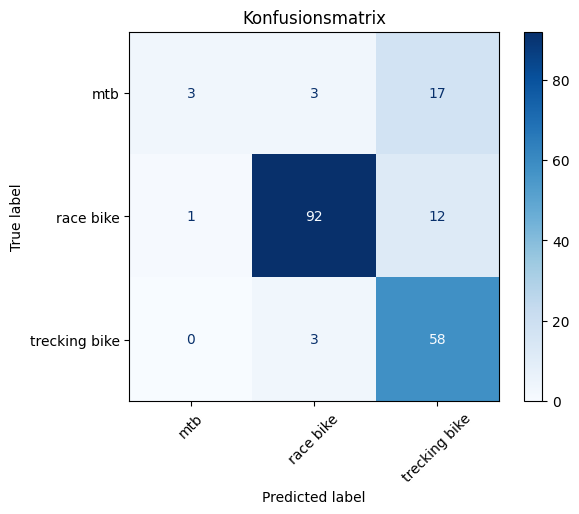

```python
# Konfusionsmatrix berechnen
cm = confusion_matrix(true_labels, predictions, labels=bike_type_states)

# Konfusionsmatrix anzeigen
disp = ConfusionMatrixDisplay(confusion_matrix=cm, display_labels=bike_type_states)
disp.plot(cmap='Blues', xticks_rotation=45)
plt.title("Konfusionsmatrix")
plt.show()
```

Wir erkennen, dass das `trecking bike` fast immer korrekt klassifiziert wird.  
Das `race bike` wird in den meisten Fällen richtig erkannt, einige Fälle werden jedoch fälschlicherweise als `trecking bike` interpretiert.  
Das größte Problem besteht beim `mtb`, da es fast nie korrekt klassifiziert wird und in der Mehrzahl der Fälle ebenfalls als `trecking bike` eingeordnet wird.

#### 4.2 Diskussion der Ergebnisse

Die Vorhersagen des Bayes-Netzes wurden mit den tatsächlichen Labels verglichen, wobei die folgenden Metriken ermittelt wurden:

| Metrik | Wert |
| --- | --- |
| **Accuracy** | 0.81 |
| **Precision (Macro Average)** | 0.79 |
| **Recall (Macro Average)** | 0.65 |
| **F1-Score (Macro Average)** | 0.64 |

**Interpretation:**

- Das Modell erreicht eine insgesamt gute Genauigkeit (81 %), was bedeutet, dass die Mehrheit der Vorhersagen korrekt ist.
- `race bike` werden mit sehr hoher Präzision (0.94) und Recall (0.88) erkannt – das Modell ist hier besonders zuverlässig.
- `trecking bike` werden ebenfalls gut erkannt (Recall: 0.95), jedoch mit einer geringeren Präzision (0.67), was auf einige Verwechslungen mit anderen Klassen hinweist.
- `mtb` bereiten dem Modell größere Probleme: Der Recall ist mit 0.13 sehr niedrig, was bedeutet, dass die meisten `mtb` fälschlich als andere Typen klassifiziert werden. Dies ist durch eine geringere Anzahl von Trainingsbeispielen und eine starke Ähnlichkeit zu den anderen Typen bedingt.

**Fazit:** Das Bayes-Netz bietet eine solide Grundlage zur Klassifikation von Fahrradtypen, insbesondere für Race Bikes. Für eine bessere Differenzierung der `mtb`-Klasse wäre es sinnvoll, eine feinere Diskretisierung oder eine alternative Modellstruktur zu erwägen.

## Aufgabenteil 2: Case Based Reasoning

Aufgabe: "Entwerfen Sie ein KI Modell auf Basis von Case Based Reasoning und setzen Sie dieses als Jupyter Notebook um. Wählen Sie geeignete Vorgehensweisen um die Fallbasis aufzubauen (CBL) und geeignete Ähnlichkeitsmaße."

Zu Beginn diskretisieren wir unsere Daten (übernommen aus Aufgabe 1).

```python
discretized_data = data[['Elapsed Time', 'Distance', 'Elevation High', 'Elevation Gain', 'Weekday', 'Bike Type']].copy()

# Diskretisierung der numerischen Spalten wie in Aufgabe 1
discretized_data['Elapsed Time'] = pd.cut(discretized_data['Elapsed Time'], bins=[0, 5666, 6810, np.inf], labels=['low', 'medium', 'high'])
discretized_data['Distance'] = pd.cut(discretized_data['Distance'], bins=[0, 35.25, 41.89, np.inf], labels=['short', 'medium', 'long'])
discretized_data['Elevation High'] = pd.cut(discretized_data['Elevation High'], bins=[-np.inf, 416.2, np.inf], labels=['low', 'high'])
discretized_data['Elevation Gain'] = pd.cut(discretized_data['Elevation Gain'], bins=[0, 279, 517, np.inf], labels=['low', 'medium', 'high'])
discretized_data['Weekday'] = discretized_data['Weekday'].apply(lambda x: 'weekend' if x in ['Saturday', 'Sunday'] else 'weekday')
```

### 1. Ähnlichkeitsmaß definieren

Im CBR-Ansatz geht man davon aus, dass ähnliche Fälle zu ähnlichen Ergebnissen (hier: Klassifikation des `Bike Type`) führen.  
Da in unserem Fall alle relevanten Merkmale (wie `Elapsed Time`, `Distance`, `Elevation High`, `Elevation Gain` und `Weekday`) bereits diskretisiert vorliegen, verwenden wir einen gewichteten Matching-Koeffizienten:

- Für jedes Merkmal prüfen wir, ob beide Fälle identisch sind.
- Wir vergeben pro Übereinstimmung einen gewichteten Punktanteil und summieren alle Bewertungen.

Somit erhalten wir am Ende einen Ähnlichkeitswert zwischen 0 und 1.

Im folgenden Beispiel kommen unterschiedliche Gewichte zum Einsatz. Diese können – je nach Fachwissen und empirischer Validierung – angepasst werden.

```python
def aehnlichkeit(fall1, fall2):
    """
    Berechnet die Ähnlichkeit zwischen zwei Fällen anhand diskreter Merkmalsausprägungen.
    Es wird ein gewichteter Matching-Koeffizient verwendet.

    Args:
        fall1 (dict): Ein Fall als Dictionary mit diskretisierten Merkmalen.
        fall2 (dict): Ein Fall als Dictionary mit diskretisierten Merkmalen.

    Returns:
        float: Ein Wert zwischen 0 und 1, der die Ähnlichkeit angibt.
    """

    # Merkmale, die für den Vergleich berücksichtigt werden sowie die Gewichte für die einzelnen Merkmale
    merkmale_und_gewichte = {
        'Elapsed Time': 0.5,
        'Distance': 0.25,
        'Elevation High': 0.25,
        'Elevation Gain': 0.25,
        'Weekday': 0.2
    }

    score = 0.0
    gesamtgewicht = sum(merkmale_und_gewichte.values())

    for merkmal, gewicht in merkmale_und_gewichte.items():
        # Falls beide Fälle im jeweiligen Merkmal übereinstimmen, wird das Gewicht addiert.
        if fall1.get(merkmal) == fall2.get(merkmal):
            score += gewicht

    # Normierung auf den Bereich [0,1]
    return score / gesamtgewicht
```

Test am Beispiel:

```python
# Wir nutzen die zuvor diskretisierten Daten
fall1 = discretized_data.iloc[0].to_dict()
fall2 = discretized_data.iloc[1].to_dict()

print(fall1)
print(fall2)

print("Ähnlichkeit: ", aehnlichkeit(fall1, fall2))
```

```
{'Elapsed Time': 'high', 'Distance': 'medium', 'Elevation High': 'high', 'Elevation Gain': 'medium', 'Weekday': 'weekend', 'Bike Type': 'mtb'}
{'Elapsed Time': 'low', 'Distance': 'short', 'Elevation High': 'high', 'Elevation Gain': 'low', 'Weekday': 'weekday', 'Bike Type': 'race bike'}
Ähnlichkeit:  0.1724137931034483
```

#### Begründung zur Wahl des Ähnlichkeitsmaßes

- Diskrete Merkmalsausprägungen: Da alle relevanten Merkmale diskretisiert wurden (analog zu Teil 1), bietet sich ein Matching-Koeffizient an, der per Feature prüft, ob die Ausprägungen übereinstimmen.
- Gewichtete Kombination: Unterschiedliche Merkmale können unterschiedliche Relevanz besitzen. Mit gewichteter Aggregation lässt sich etwa abbilden, dass die Fahrzeit oder die Distanz stärker ins Gewicht fallen als der Wochentag.
- Einfachheit und Interpretierbarkeit: Der Ansatz ist nachvollziehbar und ermöglicht eine einfache Anpassung der Gewichte je nach empirischer Evaluation.

### 2. CBR Zyklus umsetzen

Die folgende Vergleichsfunktion `finde_aehnlichsten_fall` iteriert über die Fallbasis (hier ein DataFrame) und gibt den Index, den Ähnlichkeitswert sowie den zugehörigen Fall zurück, um den ähnlichsten Fall zu bestimmen.

```python
def finde_aehnlichsten_fall(df, person_zu_vergleichen):
    """
    Findet den Fall im DataFrame, der den höchsten Ähnlichkeitswert zur gegebenen Person hat.

    Args:
        df (pd.DataFrame): DataFrame mit den diskretisierten Fahrtdaten und zugehörigen Labels.
        person_zu_vergleichen (dict): Merkmalswerte des neuen Falls.

    Returns:
        tuple: (index, höchster Ähnlichkeitswert, Fall als Series)
    """
    # Initialisierung der Variablen
    max_aehnlichkeit = -1 # Der Wert max_aehnlichkeit wird mit -1 initialisiert, um sicherzustellen, dass jede berechnete Ähnlichkeit (die immer positiv ist) den Anfangswert überschreitet und der erste Vergleich immer wahr ist.
    index_aehnlichster_fall = -1 # Platzhalter für den Index des ähnlichsten Falls
    aehnlichster_datensatz = None

    for i, row in df.iterrows():
        fall = row.to_dict()
        # Berechnung der Ähnlichkeit basierend auf den definierten Merkmalen
        a = aehnlichkeit(person_zu_vergleichen, fall)
        if a > max_aehnlichkeit:
            max_aehnlichkeit = a
            index_aehnlichster_fall = i
            aehnlichster_datensatz = row

    return index_aehnlichster_fall, max_aehnlichkeit, aehnlichster_datensatz
```

Wir testen die Funktion mit fitiven Daten:

```python
fall_fiktiv = {'Elapsed Time': 'high', 'Distance': 'long', 'Elevation High': 'high',
            'Elevation Gain': 'medium', 'Weekday': 'weekday'}

idx, sim, retrieved = finde_aehnlichsten_fall(discretized_data, fall_fiktiv)
print("Index:", idx)
print("Ähnlichkeit:", sim)
print("Ähnlichster Datensatz:\n", retrieved)

bike_type = retrieved['Bike Type']
print(f"Daher sollte das Fahrrad vom Type {bike_type} sein.")
```

```
Index: 42
Ähnlichkeit: 1.0
Ähnlichster Datensatz:
 Elapsed Time           high
Distance               long
Elevation High         high
Elevation Gain       medium
Weekday             weekday
Bike Type         race bike
Name: 42, dtype: object
Daher sollte das Fahrrad vom Type race bike sein.
```

Erstellung einer Fallbasis (CBL Zyklus)

```python
cases = pd.DataFrame(columns=['Elapsed Time', 'Distance', 'Elevation High', 'Elevation Gain', 'Weekday', 'Bike Type'])
```

Die Fallbasis ist zunächst leer. Diese wird nun nach dem CBL Algorithmus gefüllt. Vorgehen: Ein Fall wird aufgenommen, wenn er bisher nicht richtig klassifiziert wird.

```python
# Füge den ersten Eintrag von data zu cases hinzu (initialisieren)
initial = discretized_data.iloc[0]
cases = pd.concat([cases, initial.to_frame().T], ignore_index=True)
```

Die folgende Schleife iteriert durch die `discretized_data`-Daten und führt für jede Zeile den Vergleich mit der Fallbasis durch, um den ähnlichsten Fall zu finden. Falsch klassifizierte Fälle werden in die Fallbasis `cases` aufgenommen.

```python
for index, row in discretized_data.iterrows():
    # Finde den ähnlichsten Fall in "cases"
    i, m, case = finde_aehnlichsten_fall(cases, row)

    # Vergleiche den Bike Type des gefundenen Falls mit dem Bike Type des aktuellen Falls
    if case['Bike Type'] != row['Bike Type']:
        # Füge den Datensatz zu "cases" hinzu
        cases = pd.concat([cases, row.to_frame().T], ignore_index=True)
```

```python
print(f"Der Datensatz der Größe {len(discretized_data)} wurde in {len(cases)} Fällen gespeichert.")
```

```
Der Datensatz der Größe 189 wurde in 66 Fällen gespeichert.
```

Die Funktion `treffer` überprüft, wie oft die Funktion `finde_aehnlichsten_fall` den korrekten Fahrradtyp findet, indem sie für jedes Element im `discretized_data`-DataFrame den ähnlichsten Fall aus der Fallbasis `cases` sucht. Wenn der Fahrradtyp des gefundenen Falls mit dem der aktuellen Zeile übereinstimmt, wird die Anzahl der korrekten Übereinstimmungen erhöht. Fehlerhafte Übereinstimmungen werden mit einer Ausgabe des betroffenen Datensatzes angezeigt.

```python
def treffer(discretized_data, cases):
    """
    Überprüft, wie oft finde_aehnlichsten_fall den korrekten Bike Type findet.

    Args:
        data: Der DataFrame, dessen Elemente geprüft werden sollen.
        cases: Der DataFrame, in dem nach ähnlichen Fällen gesucht wird.

    Returns:
        int: Anzahl der korrekten Übereinstimmungen.
    """

    korrekte_uebereinstimmungen = 0
    for index, row in discretized_data.iterrows():
        _, _, case = finde_aehnlichsten_fall(cases, row)
        if case['Bike Type'] == row['Bike Type']:
            korrekte_uebereinstimmungen += 1
        else:
            print(f"Fehler in Datensatz {index}")

    return korrekte_uebereinstimmungen
```

Aufruf der Funktion `treffer` mit den diskretisierten Daten und den Fällen

```python
anzahl_korrekte_uebereinstimmungen = treffer(discretized_data, cases)

print("Anzahl korrekter Übereinstimmungen:", anzahl_korrekte_uebereinstimmungen)
```

```
Fehler in Datensatz 7
Fehler in Datensatz 10
Fehler in Datensatz 11
Fehler in Datensatz 16
Fehler in Datensatz 19
Fehler in Datensatz 30
Fehler in Datensatz 50
Fehler in Datensatz 53
Fehler in Datensatz 69
Fehler in Datensatz 75
Fehler in Datensatz 77
Fehler in Datensatz 79
Fehler in Datensatz 80
Fehler in Datensatz 86
Fehler in Datensatz 89
Fehler in Datensatz 94
Fehler in Datensatz 100
Fehler in Datensatz 102
Fehler in Datensatz 104
Fehler in Datensatz 107
Fehler in Datensatz 119
Fehler in Datensatz 124
Fehler in Datensatz 136
Fehler in Datensatz 139
Fehler in Datensatz 147
Fehler in Datensatz 150
Fehler in Datensatz 151
Fehler in Datensatz 162
Fehler in Datensatz 164
Fehler in Datensatz 166
Fehler in Datensatz 177
Fehler in Datensatz 178
Fehler in Datensatz 181
Fehler in Datensatz 182
Fehler in Datensatz 186
Fehler in Datensatz 189
Fehler in Datensatz 193
Fehler in Datensatz 196
Fehler in Datensatz 197
Fehler in Datensatz 198
Fehler in Datensatz 206
Fehler in Datensatz 208
Fehler in Datensatz 209
Fehler in Datensatz 212
Fehler in Datensatz 214
Fehler in Datensatz 220
Fehler in Datensatz 225
Fehler in Datensatz 226
Fehler in Datensatz 235
Fehler in Datensatz 246
Anzahl korrekter Übereinstimmungen: 139
```

### 3. Test und Bewertung

#### 3.1 Test

Es erfolgt die Klassifikation des `Bike Type` anhand des ähnlichsten Falls aus der Fallbasis,  
basierend auf den zuvor definierten, diskretisierten Testdaten.  
Für jedes Beispiel im Testdatensatz wird der CBR-Zyklus durchlaufen, und die vorhergesagte Klasse wird mit dem tatsächlichen Label verglichen,  
um die Leistungsfähigkeit des CBR-Modells zu evaluieren.

```python
# 1. Vorhersagen erzeugen
y_true = []
y_pred = []

for index, row in discretized_data.iterrows():
    _, _, case = finde_aehnlichsten_fall(cases, row)
    y_true.append(row['Bike Type'])
    y_pred.append(case['Bike Type'])

# 2. Report erstellen
report = classification_report(y_true, y_pred)
print(report)
```

```
               precision    recall  f1-score   support

          mtb       0.28      0.30      0.29        23
    race bike       0.91      0.78      0.84       105
trecking bike       0.68      0.82      0.74        61

     accuracy                           0.74       189
    macro avg       0.62      0.63      0.62       189
 weighted avg       0.76      0.74      0.74       189
```

Zusätzlich wird eine Konfusionsmatrix erstellt, um die Vorhersageergebnisse zu visualisieren.

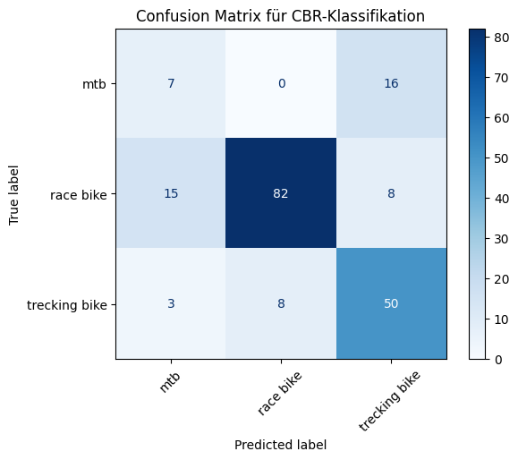

```python
cm = confusion_matrix(y_true, y_pred, labels=discretized_data['Bike Type'].unique())
disp = ConfusionMatrixDisplay(confusion_matrix=cm, display_labels=discretized_data['Bike Type'].unique())
disp.plot(cmap='Blues', xticks_rotation=45)
plt.title("Confusion Matrix für CBR-Klassifikation")
plt.show()
```

`trecking bike` und `race bike` werden in den meisten Fällen korrekt klassifiziert, jedoch bereitet die `mtb`-Kategorie erneut erhebliche Probleme: Sie wird erneut nur seltenrichtig erkannt und meistens fälschlicherweise als `trecking bike` klassifiziert.

#### 3.2 Diskussion der Ergebnisse

Die Vorhersagen des CBR-Klassifikators wurden mit den tatsächlichen Labels verglichen, wobei die folgenden Metriken ermittelt wurden:

| Metrik | Wert |
| --- | --- |
| **Accuracy** | 0.74 |
| **Precision (Macro Average)** | 0.62 |
| **Recall (Macro Average)** | 0.63 |
| **F1-Score (Macro Average)** | 0.62 |

**Interpretation:**

- Das Modell erreicht eine insgesamt ordentliche Genauigkeit (74 %), was bedeutet, dass etwa drei Viertel aller Vorhersagen korrekt sind.
- `race bike` werden mit sehr hoher Präzision (0.91) und gutem Recall (0.78) erkannt – das Modell ist hier besonders zuverlässig.
- `trecking bike` werden mit einem Recall von 0.82 ebenfalls gut erkannt. Die geringere Präzision (0.68) zeigt jedoch, dass es einige Verwechslungen mit anderen Fahrradtypen gibt.
- `mtb` stellen die größte Herausforderung dar: Mit einer Precision von 0.28 und einem Recall von 0.30 erkennt das Modell diese Klasse nur unzureichend. Viele MTBs werden fälschlicherweise als andere Typen klassifiziert (haupsächlich als `trecking bike`).

**Mögliche Ursachen:**

- **Datenungleichgewicht**: Die Kategorie `mtb` ist mit nur 23 von 189 Fällen unterrepräsentiert. Die geringe Anzahl an Beispielen erschwert dem CBR-Modell das zuverlässige Lernen typischer Merkmalskombinationen.
- **Ähnlichkeitsstruktur der Daten**: In den verwendeten diskretisierten Merkmalen ähneln sich `mtb` und `trecking bike`, was zu Fehlklassifikationen führt.
- **Gewichtung der Merkmale**: Die aktuell verwendeten Gewichte könnten für die Unterscheidung der `mtb`-Klasse weniger geeignet sein. Eine feinere Justierung oder lernbasierte Gewichtsanpassung könnte die Leistung verbessern.

**Fazit:** Das CBR-Modell liefert gute Ergebnisse für die dominante und gut unterscheidbare Klassen `race bike` und `trecking bike`. Die Leistung für die unterrepräsentierte Klasse `mtb` ist jedoch ungenügend. Eine Erweiterung der Fallbasis, eine Optimierung des Ähnlichkeitsmaßes oder eine Kombination mit anderen Ansätzen könnten die Klassifikationsleistung weiter verbessern.

# Abschluss

## Bayes-Netz

In diesem Schritt wurde die Klassifikation des Fahrradtyps auf Basis eines Bayes-Netzes getestet. Die diskretisierten Testdaten wurden als Evidenz verwendet, um für jedes Beispiel eine Wahrscheinlichkeitsverteilung über die möglichen Fahrradtypen zu berechnen. Die Vorhersage erfolgte jeweils durch Auswahl der Klasse mit der höchsten Wahrscheinlichkeit. Die tatsächlichen Labels wurden mit den Vorhersagen verglichen, um die Modellgüte zu bewerten.

Accuracy: 0.81

## CBR-Modell

Das CBR-Modell klassifiziert jeden Fall basierend auf dem ähnlichsten bekannten Fall in der Fallbasis. Auch hier wurden die diskretisierten Testdaten verwendet, um ein Matching durchzuführen. Die tatsächlichen Labels wurden wiederum mit den Vorhersagen verglichen.

Accuracy: 0.74

## Vergleich beider Modelle

Die folgende Tabelle fasst die wichtigsten Metriken zusammen:

| Modell | Accuracy | Precision (Macro) | Recall (Macro) | F1-Score (Macro) |
| --- | --- | --- | --- | --- |
| Bayes-Netz | 0.81 | 0.79 | 0.65 | 0.64 |
| CBR-Modell | 0.74 | 0.62 | 0.63 | 0.62 |

Zur besseren Veranschaulichung wird nachfolgend ein Balkendiagramm dargestellt, das die wichtigsten Metriken der beiden Modelle gegenüberstellt.

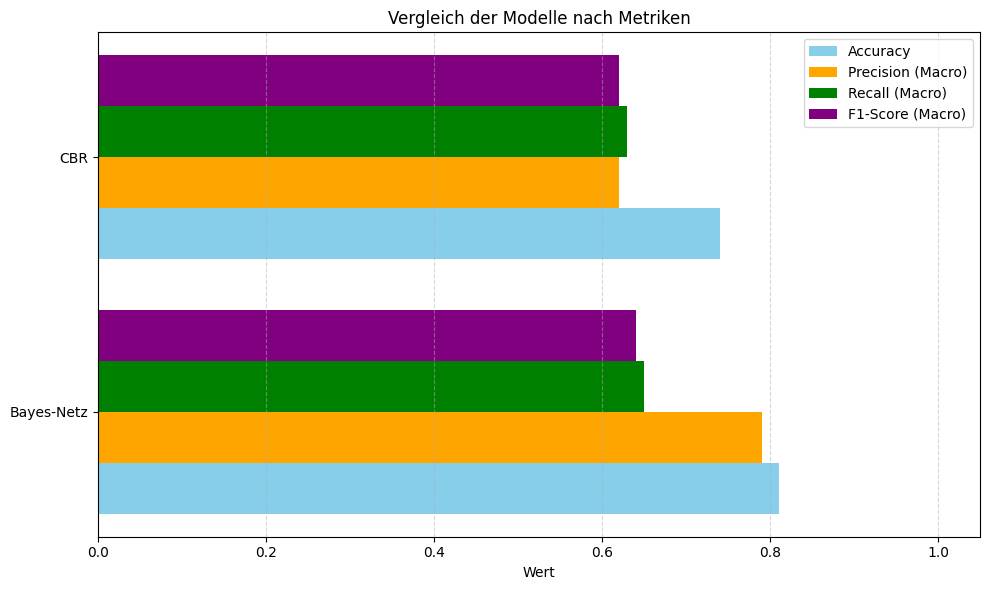

```python
models = ['Bayes-Netz', 'CBR']

# Metriken für die beiden Modelle
accuracy = [0.81, 0.74]
precision = [0.79, 0.62]
recall = [0.65, 0.63]
f1_score = [0.64, 0.62]

x = np.arange(len(models))
width = 0.2

fig, ax = plt.subplots(figsize=(10, 6))

# Positionierung der Balken
x = np.arange(len(models))
width = 0.2

# Balken für jede Metrik hinzufügen
ax.barh(x - 1.5 * width, accuracy, width, label='Accuracy', color='skyblue')
ax.barh(x - 0.5 * width, precision, width, label='Precision (Macro)', color='orange')
ax.barh(x + 0.5 * width, recall, width, label='Recall (Macro)', color='green')
ax.barh(x + 1.5 * width, f1_score, width, label='F1-Score (Macro)', color='purple')

# Achsenbeschriftungen und Titel
ax.set_xlabel('Wert')
ax.set_title('Vergleich der Modelle nach Metriken')
ax.set_yticks(x)
ax.set_yticklabels(models)
ax.set_xlim(0, 1.05)
ax.legend()

# Gridlinien hinzufügen
plt.grid(axis='x', linestyle='--', alpha=0.5)
plt.tight_layout()
plt.show()
```

### Fazit

**Stärken des Bayes-Netzes:**

- Liefert konsistente und robuste Vorhersagen, insbesondere bei gut vertretenen Klassen wie `race bike`.
- Die probabilistische Struktur ermöglicht eine differenzierte Entscheidungsfindung auf Basis der kombinierten Evidenz.

**Stärken des CBR-Modells:**

- Vergleichbare Gesamtleistung trotz einfacherer Struktur.
- Sehr gut interpretierbar und flexibel erweiterbar durch neue Fälle.
- Besonders effektiv bei Klassen mit eindeutigen Merkmalsprofilen (z. B. `race bike`), zeigt jedoch Schwächen bei der Differenzierung ähnlicher bzw. unterrepräsentierter Klassen wie `mtb`.

**Ausblick:** Zur weiteren Optimierung beider Ansätze bieten sich spezifische Verbesserungsmöglichkeiten an.  
Für das **Bayes-Netz** könnte eine **feinere Diskretisierung** sowie eine **Erweiterung der CPT-Struktur** die Modellleistung weiter steigern, insbesondere im Hinblick auf seltenere Merkmalskombinationen.  
Das **CBR-Modell** hingegen könnte durch eine gezielte **Gewichtsanpassung** im Ähnlichkeitsmaß profitieren. Zudem wäre eine **bessere Repräsentation seltener Klassen** wünschenswert, um die Klassifikation unterrepräsentierter Typen wie `mtb` zu verbessern.